# Pipeline results

*Authors: Rick Beeloo & Koen van der Heide*

### Goal

Unraveling the function of a protein is valuable in understanding its role in an organisms and may aid in drug discovery. Although tons of proteins have been annotated in recent years, many times a researcher will encounter proteins with function descriptions like ‘unknown’ or ‘hypothetical’. Such information is undoubtedly essential in experiments where such genes bind to your protein of interest or show differential expression. Direct prediction of a proteins function is hard if not impossible, however research can mostly derive this form annotation instantly. Hence, we wrote a script gathering such information. Two parts can be distinguished:

- **BLAST independent**, analysis solely based on the FASTA input:
  - PHOBIUS, subcellular location
  - InterPro, motif in the protein sequence
- **BLAST dependent**, analsyis based on proteins similar to the inputted protein:
  - MSA, highlighting conserved amino acids (perhaps functional ones)
  - Literature, articles mentioning similar genes
  - STRING, interactions of the similar proteins
  - KEGG, Pathways of the similar genes

### Input

**Note** You gave r.beeloo@outlook.com as mail address, hence you could receive emails from the web services used in this pipeline when for example an error occurred or a limit exceeded. The following FASTA was analyzed:

| >YP_004888459.1 6-phospho-beta-glucosidase [Lactobacillus plantarum WCFS1] |
| --- |
| MTIKGRAFPEGFLWGGAVAAHQLEGGYKEGGKGLSTADIMTLGTNERPREITDGVVAGKYYPNHQAIDFY |

### Protein location (Phobius)

Location is a fundamental aspect of a proteins function, therefore we used the well-known PHOBIUS algorithm to predict this for the input sequence.

**Visual output**

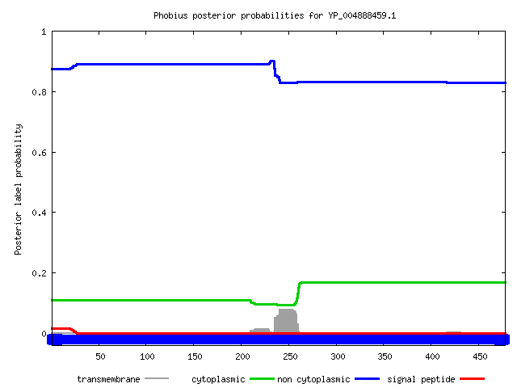

**Textual output**

```
## [1] "ID   YP_004888459.1"
## [2] "FT   DOMAIN        1    478       NON CYTOPLASMIC."
## [3] "//"
```

Information about how to interpret this information can be found [here](http://phobius.sbc.su.se/instructions.html).

### Motifs and domains (InterPro)

Motifs and domains often provide valuable clues regarding the function of a protein. For example whenever a DNA binding site is present in a protein the number of possibile functions greatly reduces. Such information is available in various databases such as PFAM, CDD, ProSite etc. All these can be queried simultaneously using InterPro.

**Visual output**

[figure not shown]

**Textual output**

Unfortunately the textual output does not have a header, nonetheless it’s easy interpretable.

YP_004888459.1

68264c746e949f412140ed69ed448c70

478

ProSitePatterns

PS00653

Glycosyl hydrolases family 1 N-terminal signature.

12

26

TRUE

08-06-2018

IPR033132

Glycosyl hydrolases family 1, N-terminal conserved site

NA

YP_004888459.1

68264c746e949f412140ed69ed448c70

478

PANTHER

PTHR10353

6

474

3.1E-233

TRUE

08-06-2018

IPR001360

Glycoside hydrolase family 1

GO:0004553|GO:0005975

NA

YP_004888459.1

68264c746e949f412140ed69ed448c70

478

Pfam

PF00232

Glycosyl hydrolase family 1

7

474

7.7E-134

TRUE

08-06-2018

IPR001360

Glycoside hydrolase family 1

GO:0004553|GO:0005975

NA

YP_004888459.1

68264c746e949f412140ed69ed448c70

478

Gene3D

G3DSA:3.20.20.80

1

478

9.7E-175

TRUE

08-06-2018

NA

YP_004888459.1

68264c746e949f412140ed69ed448c70

478

PRINTS

PR00131

Glycosyl hydrolase family 1 signature

308

322

5.8E-17

TRUE

08-06-2018

IPR001360

Glycoside hydrolase family 1

GO:0004553|GO:0005975

NA

YP_004888459.1

68264c746e949f412140ed69ed448c70

478

PRINTS

PR00131

Glycosyl hydrolase family 1 signature

392

403

5.8E-17

TRUE

08-06-2018

IPR001360

Glycoside hydrolase family 1

GO:0004553|GO:0005975

NA

YP_004888459.1

68264c746e949f412140ed69ed448c70

478

PRINTS

PR00131

Glycosyl hydrolase family 1 signature

439

451

5.8E-17

TRUE

08-06-2018

IPR001360

Glycoside hydrolase family 1

GO:0004553|GO:0005975

NA

YP_004888459.1

68264c746e949f412140ed69ed448c70

478

PRINTS

PR00131

Glycosyl hydrolase family 1 signature

371

379

5.8E-17

TRUE

08-06-2018

IPR001360

Glycoside hydrolase family 1

GO:0004553|GO:0005975

NA

YP_004888459.1

68264c746e949f412140ed69ed448c70

478

PRINTS

PR00131

Glycosyl hydrolase family 1 signature

414

431

5.8E-17

TRUE

08-06-2018

IPR001360

Glycoside hydrolase family 1

GO:0004553|GO:0005975

NA

YP_004888459.1

68264c746e949f412140ed69ed448c70

478

SUPERFAMILY

SSF51445

7

470

6.35E-166

TRUE

08-06-2018

IPR017853

Glycoside hydrolase superfamily

NA

YP_004888459.1

68264c746e949f412140ed69ed448c70

478

ProSitePatterns

PS00572

Glycosyl hydrolases family 1 active site.

371

379

TRUE

08-06-2018

IPR018120

Glycoside hydrolase family 1, active site

NA

YP_004888459.1

68264c746e949f412140ed69ed448c70

478

PANTHER

PTHR10353:SF85

6

474

3.1E-233

TRUE

08-06-2018

NA

### BLAST

Arguably the easiest way to derive the function of a protein is to find a protein that looks like the protein of interest and simply assume that whenever the match is ‘good’ that the function will be the same. Therefore a BLAST was performed against uniprotkb_bacteria with a maximum number of alignments of 100. Hereafter, the significant matches were determined based on an E-value cut-off of 0.05 and a identity% greater than 80.

**Visual output**

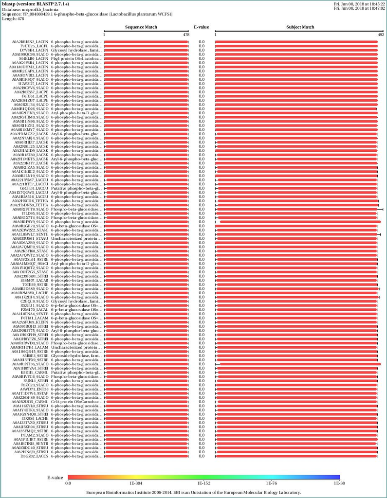

### Uniprot

The protein sequences and annotation for the significant BLAST matches was retrieved from UniProt. Based on this annotation the matches were splitted based on the criteria of whether these originated from the same or a different species. Although the definition of paralogs and orthologs is much stricter, we refer to the former as paralogs and the latter as orthologs. This split resulted in 1 paralogs and 98 orthologs.

**Paralog annotation**

| Entry | Entry.name | Protein.names | EC.number | Organism | Organism.ID | Gene.names | Pathway | Gene.ontology..biological.process. |
| --- | --- | --- | --- | --- | --- | --- | --- | --- |
| F9UU25 | F9UU25_LACPL | 6-phospho-beta-glucosidase (EC 3.2.1.86) | 3.2.1.86 | Lactobacillus plantarum (strain ATCC BAA-793 / NCIMB 8826 / WCFS1) | 220668 | pbg1 lp_0440 | NA | carbohydrate metabolic process [GO:0005975] |

**Ortholog annotation**

| Entry | Entry.name | Protein.names | EC.number | Organism | Organism.ID | Gene.names | Pathway | Gene.ontology..biological.process. |
| --- | --- | --- | --- | --- | --- | --- | --- | --- |
| A0A2K3W2Z2 | A0A2K3W2Z2_STASC | 6-phospho-beta-glucosidase |  | Staphylococcus sciuri subsp. sciuri | 147467 | CD035_05520 | NA | carbohydrate metabolic process [GO:0005975] |
| A0A0R2I3D5 | A0A0R2I3D5_CARML | CelA protein |  | Carnobacterium maltaromaticum DSM 20342 | 1449341 | IV70_GL001536 | NA | carbohydrate metabolic process [GO:0005975] |
| K8E1I1 | K8E1I1_CARML | Putative phospho-beta-glucosidase (EC 3.2.1.86) | 3.2.1.86 | Carnobacterium maltaromaticum LMA28 | 1234679 | bgl BN424_194 | NA | carbohydrate metabolic process [GO:0005975] |
| C2EQL9 | C2EQL9_9LACO | Glycosyl hydrolase, family 1 (EC 3.2.1.86) | 3.2.1.86 | Lactobacillus ultunensis DSM 16047 | 525365 | HMPREF0548_1965 | NA | carbohydrate metabolic process [GO:0005975] |
| A0A1B2A516 | A0A1B2A516_LACCU | 6-phospho-beta-glucosidase |  | Lactobacillus curvatus | 28038 | BCY75_03480 | NA | carbohydrate metabolic process [GO:0005975] |
| A0A221RTE7 | A0A221RTE7_LACCU | 6-phospho-beta-glucosidase |  | Lactobacillus curvatus | 28038 | CG419_01540 | NA | carbohydrate metabolic process [GO:0005975] |
| A0A221RYM7 | A0A221RYM7_LACCU | 6-phospho-beta-glucosidase |  | Lactobacillus curvatus | 28038 | CGZ47_01650 | NA | carbohydrate metabolic process [GO:0005975] |
| A0A1X7QGW3 | A0A1X7QGW3_LACCU | Aryl-6-phospho-beta-glucosidase (EC 3.2.1.86) | 3.2.1.86 | Lactobacillus curvatus | 28038 | bglA LCUFL03_110010 | NA | carbohydrate metabolic process [GO:0005975] |
| A0A0R1H7K4 | A0A0R1H7K4_LACAM | Uncharacterized protein |  | Lactobacillus amylovorus DSM 20531 | 1423723 | FC63_GL000930 | NA | carbohydrate metabolic process [GO:0005975] |
| A0A1H6Q3H5 | A0A1H6Q3H5_9STRE | 6-phospho-beta-glucosidase |  | Streptococcus sp. 45 | 1855326 | SAMN05216460_0142 | NA | carbohydrate metabolic process [GO:0005975] |
| A0A1K2I5I4 | A0A1K2I5I4_9LACO | 6-phospho-beta-glucosidase (EC 3.2.1.86) | 3.2.1.86 | Lactobacillus rennini | 238013 | LREN565_0615 | NA | carbohydrate metabolic process [GO:0005975] |
| A0A2H1MKT5 | A0A2H1MKT5_LACSK | Aryl-6-phospho-beta-glucosidase (EC 3.2.1.86) | 3.2.1.86 | Lactobacillus sakei | 1599 | bglA LSAJ112_20035 | NA | carbohydrate metabolic process [GO:0005975] |
| A0A2H1MGZ2 | A0A2H1MGZ2_LACSK | Aryl-6-phospho-beta-glucosidase (EC 3.2.1.86) | 3.2.1.86 | Lactobacillus sakei | 1599 | bglA LSAJ160_50011 | NA | carbohydrate metabolic process [GO:0005975] |
| A0A2N9LI25 | A0A2N9LI25_LACSK | 6-phospho-beta-glucosidase BglA (EC 3.2.1.86) | 3.2.1.86 | Lactobacillus sakei | 1599 | bglA LAS9267_01830 | NA |  |
| A0A2A7QME9 | A0A2A7QME9_9LACO | 6-phospho-beta-glucosidase |  | Lactobacillus sp. UMNPBX17 | 2042030 | CP368_00855 | NA | carbohydrate metabolic process [GO:0005975] |
| D7V8K4 | D7V8K4_LACPN | Glycosyl hydrolase, family 1 (EC 3.2.1.86) | 3.2.1.86 | Lactobacillus plantarum subsp. plantarum ATCC 14917 = JCM 1149 = CGMCC 1.2437 | 525338 | pbg HMPREF0531_10481 | NA | carbohydrate metabolic process [GO:0005975] |
| A0A2N9DT75 | A0A2N9DT75_9LACO | Aryl-6-phospho-beta-glucosidase (EC 3.2.1.86) | 3.2.1.86 | Lactobacillus fuchuensis | 164393 | bglA LFUMFP_110007 | NA |  |
| A0A0R1NT36 | A0A0R1NT36_9LACO | 6-phospho-beta-glucosidase |  | Lactobacillus gallinarum DSM 10532 = JCM 2011 | 1423748 | FC37_GL000957 | NA | carbohydrate metabolic process [GO:0005975] |
| D5GZ02 | D5GZ02_LACCS | 6-phospho-beta-glucosidase |  | Lactobacillus crispatus (strain ST1) | 748671 | bglA5 LCRIS_01564 | NA | carbohydrate metabolic process [GO:0005975] |
| A0A0R1HZR1 | A0A0R1HZR1_9LACO | 6-phospho-beta-glucosidase |  | Lactobacillus paralimentarius DSM 13961 = JCM 10707 | 1423765 | FC97_GL001142 | NA | carbohydrate metabolic process [GO:0005975] |
| U2W2D7 | U2W2D7_LACPN | 6-phospho-beta-glucosidase |  | Lactobacillus plantarum AY01 | 1358413 | N644_2202 | NA | carbohydrate metabolic process [GO:0005975] |
| A0A0U3FPX9 | A0A0U3FPX9_9STRE | 6-phospho-beta-glucosidase |  | Streptococcus infantarius | 102684 | AU079_04800 | NA | carbohydrate metabolic process [GO:0005975] |
| A0A0Z8DG40 | A0A0Z8DG40_STRSU | 6-phospho-beta-glucosidase (EC 3.2.1.86) | 3.2.1.86 | Streptococcus suis | 1307 | celA ERS132385_00809 | NA | carbohydrate metabolic process [GO:0005975] |
| A0A2I5N6J9 | A0A2I5N6J9_STRSU | 6-phospho-beta-glucosidase |  | Streptococcus suis | 1307 | CWM22_11140 | NA | carbohydrate metabolic process [GO:0005975] |
| A0A2I5KR04 | A0A2I5KR04_STRSU | 6-phospho-beta-glucosidase |  | Streptococcus suis | 1307 | CWI26_10000 | NA | carbohydrate metabolic process [GO:0005975] |
| A0A116KYL0 | A0A116KYL0_STRSU | 6-phospho-beta-glucosidase (EC 3.2.1.86) | 3.2.1.86 | Streptococcus suis | 1307 | celA ERS132416_00119 | NA | carbohydrate metabolic process [GO:0005975] |
| E8JNL1 | E8JNL1_STREI | 6-phospho-beta-glucosidase (EC 3.2.1.86) | 3.2.1.86 | Streptococcus equinus ATCC 9812 | 525379 | celA HMPREF0819_0584 | NA | carbohydrate metabolic process [GO:0005975] |
| S5R0E3 | S5R0E3_9STRE | Glycoside hydrolase, family 1 |  | Streptococcus lutetiensis 033 | 1076934 | KE3_1118 | NA | carbohydrate metabolic process [GO:0005975] |
| A0A0R1KMY7 | A0A0R1KMY7_9LACO | 6-phospho-beta-glucosidase |  | Lactobacillus paralimentarius DSM 19674 | 1423788 | FC78_GL002253 | NA | carbohydrate metabolic process [GO:0005975] |
| A0A0R1X7T4 | A0A0R1X7T4_9LACO | Phospho-beta-glucosidase |  | Lactobacillus graminis DSM 20719 | 1423752 | FC90_GL000286 | NA | carbohydrate metabolic process [GO:0005975] |

[output cut: 68 more lines]

**Uniprot sequences**

As seeing the downloaded sequences is not that useful we refer to the FASTA file of these and chose to not include these in the report directly.

**Note**: The chance of finding useful information about the protein in other species is reasonably higher than for protein from the same species. Therefore only orhologous matches were used for subsequent analysis.

### Literature search

Basically two approaches can be used to search genes in the literature, text-mining or database coupling. We chose to use the latter in this case as protein names can greatly result in false positives due to uninformative names or different namings. So we coupled the gene database to the PubMed database, thereby coupling the genes to the uploader information which greatly enhances reliability.

[output not shown]

### Kegg

The data retrieved from Uniprot such as pathway and biological process already points into the right direction, however sometimes it’s useful to look at pathway maps to infer the flow of metabolites and hence better understand the role of a protein. We could couple 13 Uniprot entries to the corresponding KEGG entry. It’s important two keep **two things** in mind when coupling proteins to KEGG:

- Not all proteins are included in KEGG. Although ideally all proteins could be mapable to KEGG, this will practically not be the case.
- A protein can be part of multiple pathways, and some pathways are sub pathways of others.

Out of the 98 Uniprot entries we were able to map 13 of them to KEGG, out of these **26** were coupled to a KEGG pathway.

[output not shown]

### Protein interactions

Until now we focused on the individual proteins, however it may be useful to look at the interactions of the similar proteins. When our best matching protein from the BLAST results interacts with for example a glucose transporter this helps to understand the function of the protein. Therefore we queried all the significant matches against the STRING database and gathered their neighbours with a limit of 20 nodes:

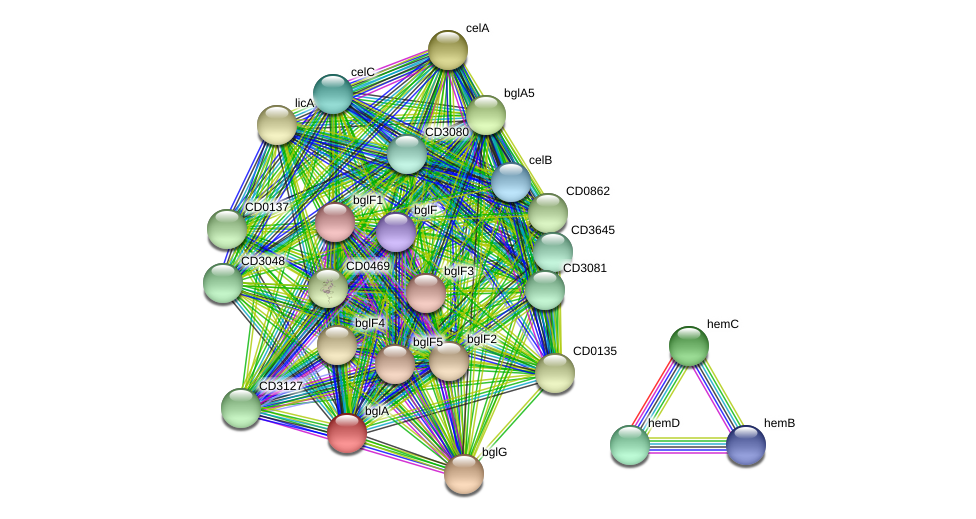

### Multiple sequence alginment (MSA)

To get insight in the conservation of such sequences a MSA was performed using T-COFFEE

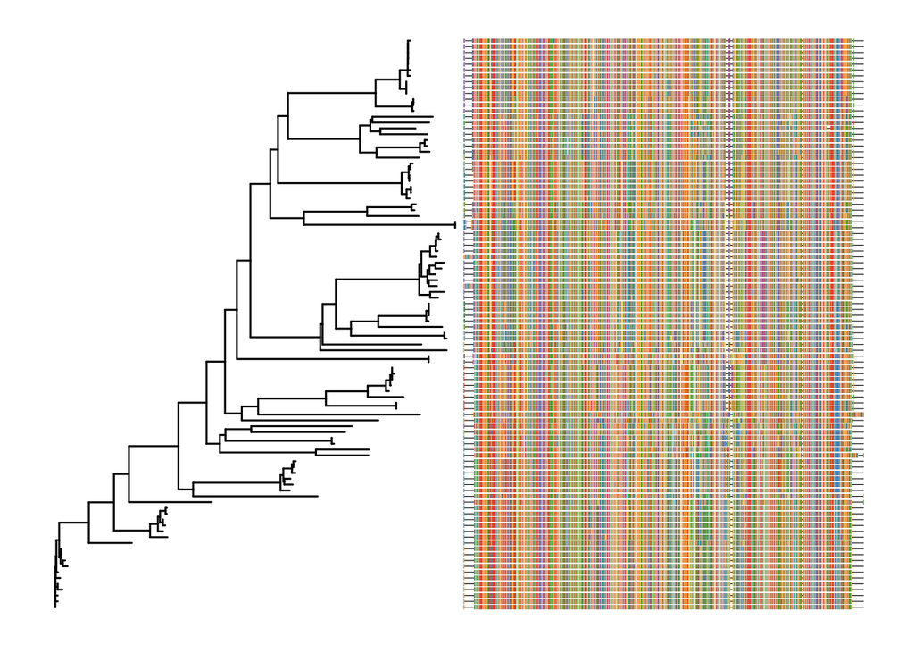

### Code

In this rapport we mainly foccused on the biological aspects of the pipeline. We chose to dedicate a gihtub repository to the technical aspects of this pipeline.